# Regression Discontinuity

## Regression discontinuity

- “A localized experiment at the cutoff point”

## Regression discontinuity

- Hard to distinguish effects of specific policies from variables that cause those policies to be implemented.
- But arbitrary cutoffs are extremely common in policy: “need” may be a complex latent characteristic that is nearly impossible to measure, but “is your household income less than 130% of the federal poverty line?” is just a check box.

## Health insurance rates by age

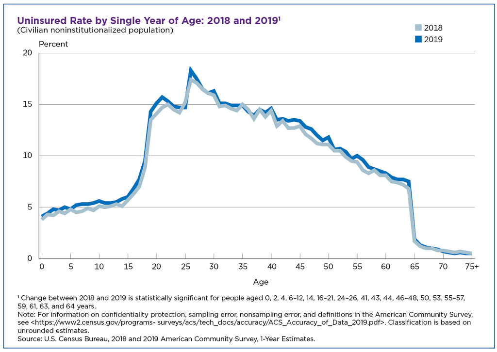

## Birth date and age at time of entering first grade

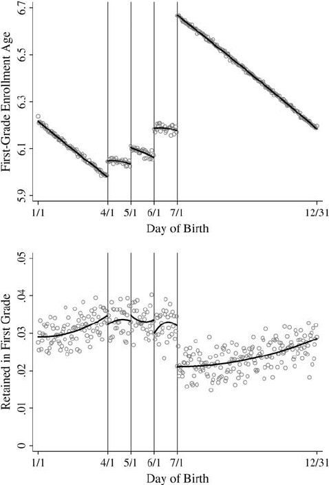

McEwan, P. J., & Shapiro, J. S. (2008). The benefits of delayed primary school enrollment: Discontinuity estimates using exact birth dates. Journal of human Resources, 43(1), 1-29.

[figure not shown]

## Discontinuity assumptions

- Characteristics like age aren’t randomly distributed, but they have a random **component.**
- As you get closer to a hard cutoff, “randomness” accounts for a proportionally larger share of the difference in outcomes: birth year is fairly non random, but being born at 11:59 PM on February 4th is not really different from being born on February 5th at 12:01 AM.
- Depending on how much noise there is, randomness could account for 100% of the difference within a window near the discontinuity.
- The causal statement here is: “but for [the cutoff] there would be a continuous line through different values of X”

## RDD essentials

- We need a **running variable** and a discontinuity/cutoff. The running variable must be ordinal/continuous
- The cutoff should impact our outcome only through its impact on the IV of interest
  - This can be problematic for things like age and income because you qualify for multiple things at age 65 or x% of the federal poverty limit
- Units near the cutoff should be as similar as possible
  - They won’t be identical by definition, but you can control for the “forcing” characteristic.
- The amount of random variation shouldn’t suddenly increase near the cutoff

## Example: Carpenter and Dobkin

- Carpenter Dobkin (2011): does setting the drinking age at 21 accomplish anything?

Observational research suggests compliance is quite low.

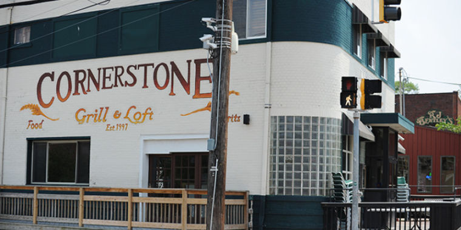

But this is a federal law, so we don’t have a reasonable comparison group.

### Minimum drinking age

However, the age cutoff itself could be a source of a discontinuity.

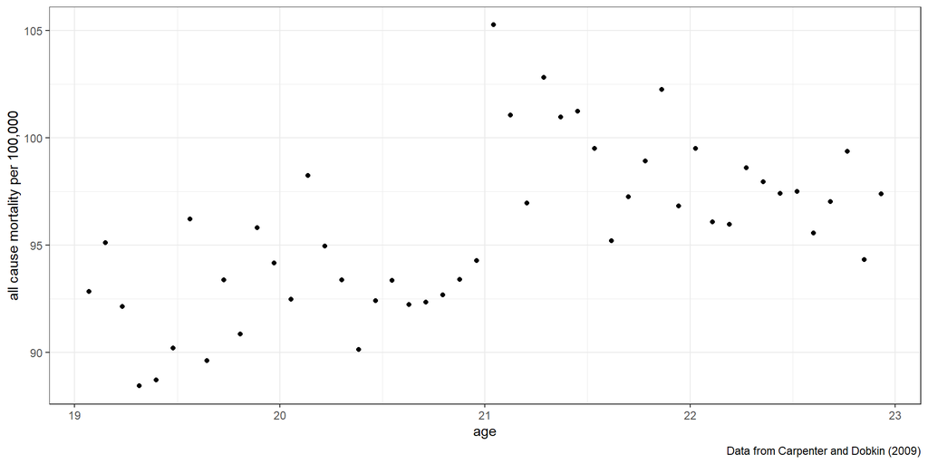

### Minimum drinking age

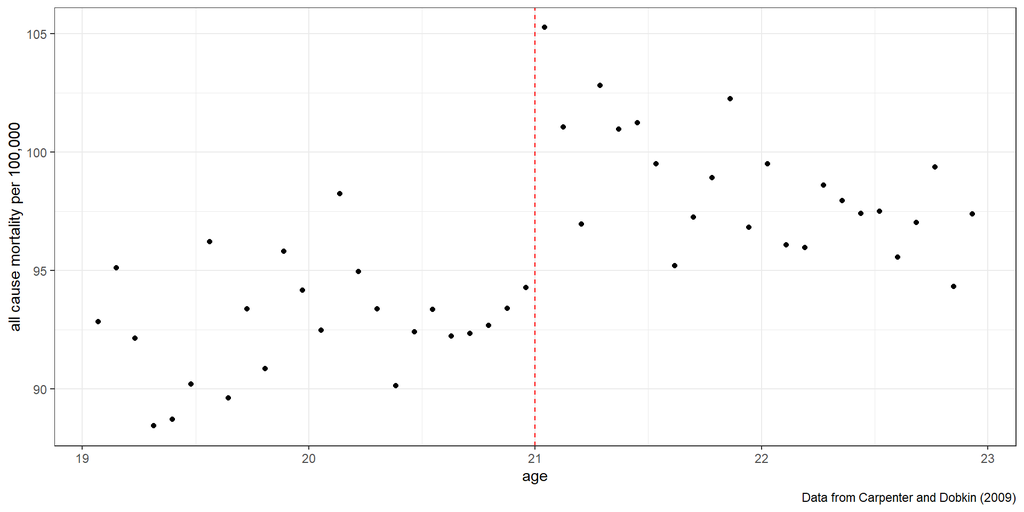

### Minimum drinking age

The simplest way to estimate the effect is a linear model with a control for the running variable and an indicator for the treatment. (we can also center the “age” at 21 to simplify the interpretation

DV = all cause mortality.

|  | model 1 |
| --- | --- |
| constant | 91.841 |
|  | [90.220, 93.463] |
| age | −0.975 |
|  | [−2.249, 0.299] |
| over 21? | 7.663 |
|  | [4.762, 10.564] |
| Num.Obs. | 48 |
| R2 | 0.595 |

Age centered at 0 = 21

That said, this probably isn’t the best method because the slopes are different before and after the cutoff.

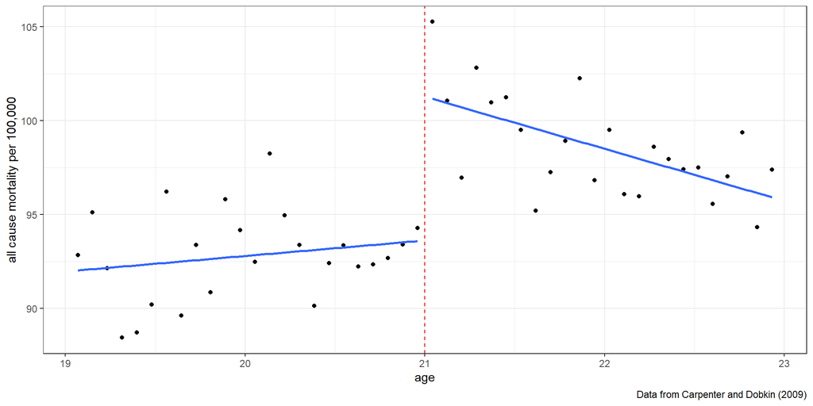

### Minimum drinking age

Using an interaction term allows the slope of the line to be different before and after the cutoff.

DV = all cause mortality.

|  | model 1 | model 2 |
| --- | --- | --- |
| constant | 91.841 | 93.618 |
|  | [90.220, 93.463] | [91.739, 95.498] |
| age | −0.975 | 0.827 |
|  | [−2.249, 0.299] | [−0.823, 2.477] |
| over 21? | 7.663 | 7.663 |
|  | [4.762, 10.564] | [5.005, 10.320] |
| age x over 21 |  | −3.603 |
|  |  | [−5.937, −1.269] |
| Num.Obs. | 48 | 48 |
| R2 | 0.595 | 0.668 |

Age centered at 0 = 21

### Minimum drinking age

- Assuming we’ve got the right model here, hitting the minimum legal drinking age results in about 8 more deaths per 100,000 people. But the negative slope after 21 might indicate the effect wears off and then *reverses*

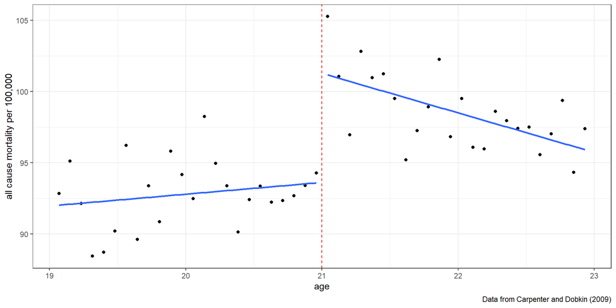

### Minimum drinking age

However, the dis-aggregated results suggest that this isn’t the case: it’s more likely there are two separate trends.

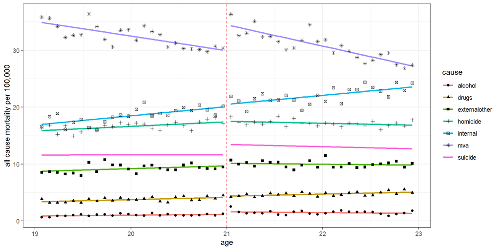

## Non-linearity

One important consideration here is accounting for non-linearity. Properly controlling for the effect of the running variable requires us to get the functional form right.

## Non-linearity

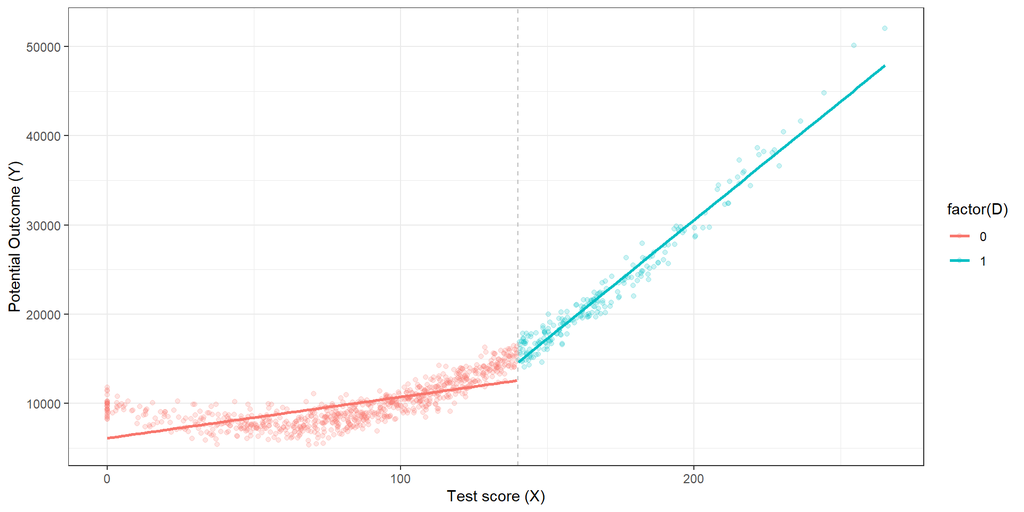

```r
set.seed(100)
# simultate nonlinearity
dat <- tibble(
    x = rnorm(1000, 100, 50)
  ) |>
  mutate(
    x = case_when(x < 0 ~ 0, TRUE ~ x),
    D = case_when(x > 140 ~ 1, TRUE ~ 0),
    x2 = x*x,
    x3 = x*x*x,
    y3 = 10000 + 0 * D - 100 * x + x2 + rnorm(1000, 0, 1000)
  ) |>
  filter(x < 280)


ggplot(aes(x, y3, colour = factor(D)), data = dat) +
  geom_point(alpha = 0.2) +
  geom_vline(xintercept = 140, colour = "grey", linetype = 2) +
  stat_smooth(method = "lm", se = F) +

  labs(x = "Test score (X)", y = "Potential Outcome (Y)") +
  theme_bw()
```

### Non-linearity

- Adding polynomials (squared, cubed, etc versions of the running variable) is one option, but
  - can result in over-fitting
  - still can’t approximate certain kinds of non-linearity

### Non-linearity: local smoothing

Methods such as LOESS operate by estimating weighted polynomial regressions on a sliding “window” (usually called the bandwidth) of data points and then smoothing that result using a kernel function*.

All else equal, a smaller window gives greater weight to individual points, while a larger window will result in a smoother line.

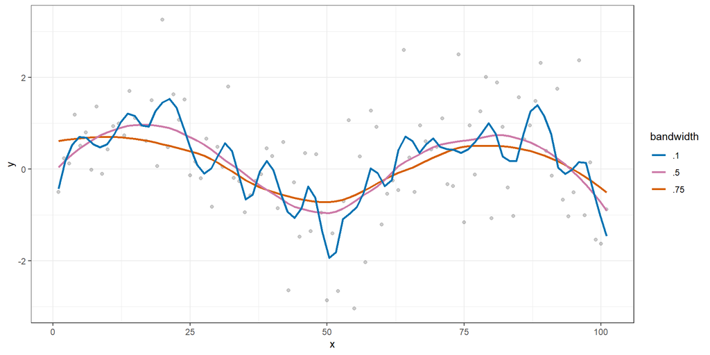

*as you might guess, this is related to the methods that generate kernel density plots

### Non-linearity: local smoothing

- Local smoothing is typically not a great tool for hypothesis testing because it doesn’t really tell you an “effect” but in the discontinuity case, we really only care about the difference around the cutoff.
- The choice of a bandwidth and kernel function adds some additional complexity, but there are some ways to estimate an optimal window.

## Example: Incumbency effects

Is the incumbency advantage real? How could we estimate it? Are there reasons to doubt it exists?

### Vote share and winning a two-party election

Obviously, there’s a built-in discontinuity here!

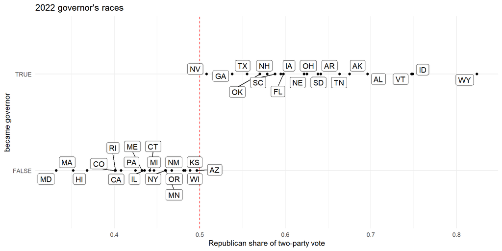

### Incumbency effects

Looking at the overall scatter plot, there’s definitely a positive correlation between winning a seat at time 1 vs. time 2, but that’s not especially surprising: popular candidates remain popular.

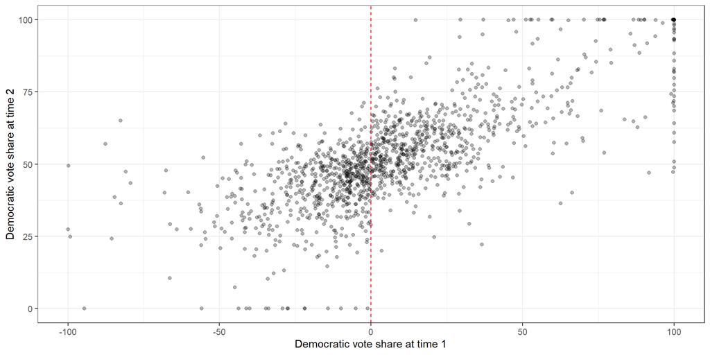

### Incumbency effects

If the incumbency effect is real, we would expect to see a sharp change near the cutoff for winning a seat.

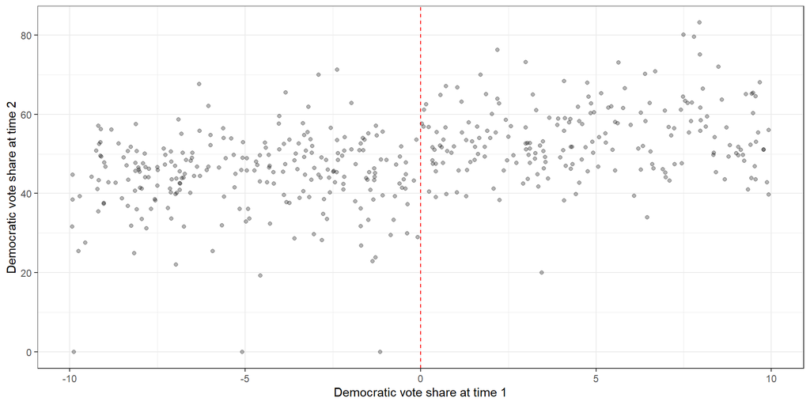

### Incumbency effects

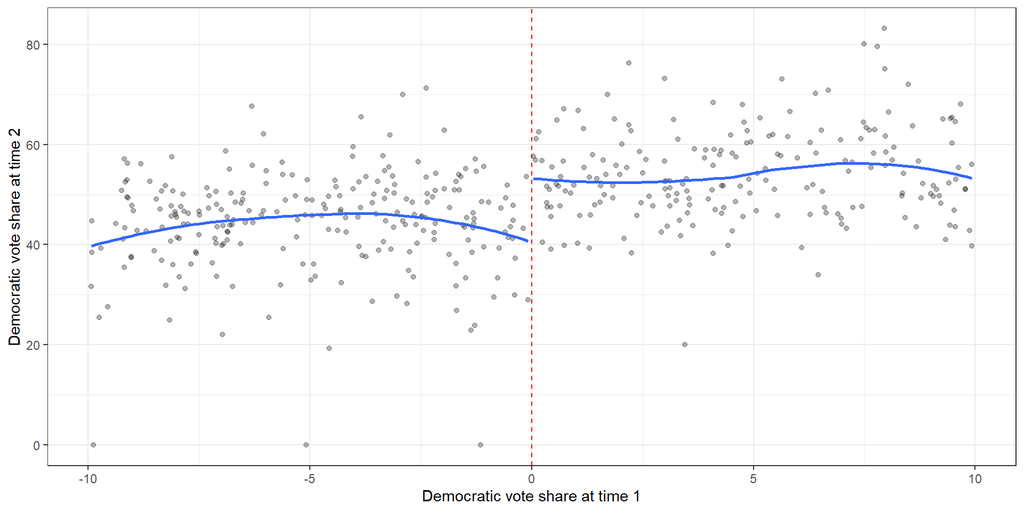

### Vote share and winning a two-party election

Using `rdrobust` to estimate an optimal bin size:

```r
library(rdrobust)

out <- rdplot(data$demshare_t2,
              data$dem_margin,
              p = 3,
              kernel ='uniform',
               x.label = 'Democratic margin at time 1',
              y.label = 'Dem voteshare at time 2', title = '', hide=TRUE)
out$rdplot
```

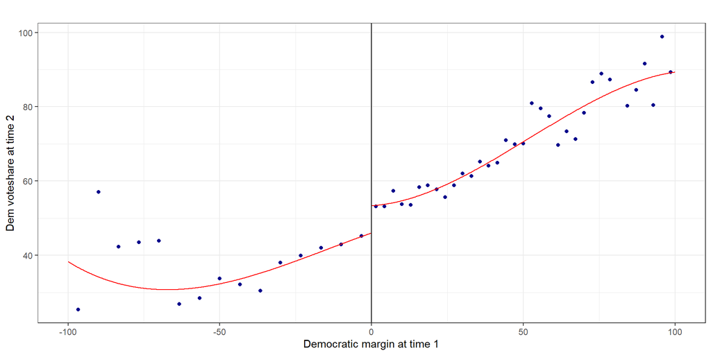

### Vote share and winning a two-party election

```r
out <- rdrobust(data$demshare_t2,
                data$dem_margin,
                kernel = 'uniform',
                c= 0,
                p = 3, bwselect = 'mserd')

data.frame(coef=out$coef, se=out$se, z=out$z, ci=out$ci)|>
  slice_head(n=1)
```

| Coeff | Std..Err. | z | ci.CI.Lower | ci.CI.Upper |
| --- | --- | --- | --- | --- |
| 9.55 | 2.21 | 4.31 | 5.21 | 13.9 |

## Testing assumptions near the cutoff

A simple test for the assumptions for RDD is to set a different cutoff and see if the results are still significant. If we’re finding an effect at winning 49%, that suggests we aren’t really seeing an incumbency effect:

```r
out <- rdplot(data$demshare_t2,
              data$dem_margin,
              p = 3,
              c = -1,
              binselect = 'esmv', x.label = 'Democratic margin at time 1',
              y.label = 'Dem voteshare at time 2', title = '', hide=TRUE)
out$rdplot +
  geom_vline(xintercept=0, lty=2, color='red')
```

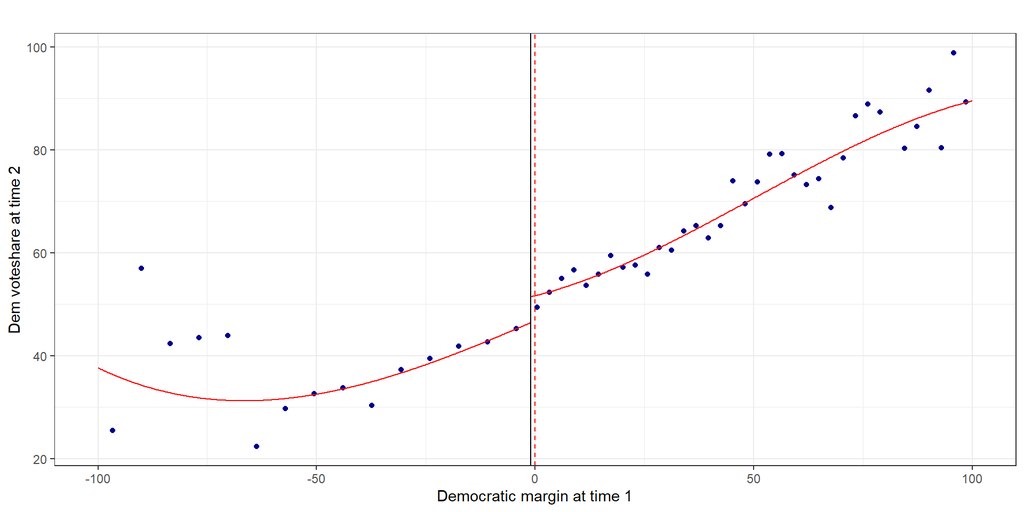

## Testing assumptions near the cutoff

```r
out <- rdrobust(data$demshare_t2,
                data$dem_margin,
                kernel = 'uniform',
                c= -1,
                p = 3,
                bwselect = 'mserd')

data.frame(coef=out$coef, se=out$se, z=out$z, ci=out$ci)|>
  slice_head(n=1)
```

| Coeff | Std..Err. | z | ci.CI.Lower | ci.CI.Upper |
| --- | --- | --- | --- | --- |
| 2.12 | 2.29 | 0.927 | -2.36 | 6.6 |

## Vote share as a discontinuity

Vote share is the most common design for political scientists

- [Cattaneo, Frandsen, and Titiunik (2014)](https://www.degruyter.com/document/doi/10.1515/jci-2013-0010/html?lang=en): the incumbency advantage for U.S. Senators
- [Meyerson (2014)](https://www.jstor.org/stable/24029175): election of Islamic political parties and educational attainment for women
- [Pettersson-Lidbom (2008)](https://www.jstor.org/stable/40283092): election of left-wing governments in Sweden and unemployment/taxation

## What are we estimating here?

- Technically, we’re estimating a local average treatment effect near the cutoff. This only matches the average treatment effect if the effects are similar across all values of the running variable. So consider:
  - People near an income threshold undoubtedly benefit more from income assistance compared to people far away
  - Swing districts may be more economically volatile than more partisan ones.
  - People around age 21 may do riskier stuff when they drink compared to older people.

Whether this matters is partly a question of interpretation.

## Fuzzy and sharp boundaries

- Plurality elections impose a sharp boundary, but other boundaries may be “soft”
  - Not everyone who is eligible for food stamps will enroll
  - Some elected officials resign or never take their seats
  - The thresholds themselves may be measured with error (blood alcohol content, registration, place of residence)
- This could be considered similar to the problem of “non-compliance”: some units should be treated, but aren’t. Methods are similar: estimate a 2 stage regression model to adjust for non-compliance

## Others

Hopkins (2004): county threshold for language minorities and ballot assistance

Posner: Regression discontinuity and cultural cleavage

## Considerations

- Are observations near the cutoff fundamentally unlike observations elsewhere?
- Is it possible some cases are changing their behavior in response to being “near” the cutoff?
- Do small changes to the method for fitting the running variable cause big changes in the estimated effect? If so, the results might be spurious.
- Does a placebo test give null results?
  - Testing “fake” cutoffs shortly before or after the real one
  - Checking for discontinuities on other variables that seem like they shouldn’t be responsive to the treatment (i.e. do homicides also spiking around 21 might indicate a different process)